# Human Activity Recognition

Coursera Practical Machine Learning: Prediction Assignment

Victor Garzon

March 30, 2016

## Summary

In this project we use machine learning to classify human physical activity using accelerometer data. We classify barbell lifts in one of five different categories. We trained a $k$-nearest neighbors classifier using variable `num_window` with accuracy of 98%. An alternative random forest model trainned on remainder variables had an estimated out-of-sample accuracy of ~95%. The estimated of out-of-sample accuracy was calculated using cross-validation.

## Setup

The data set used comes from six participants who were asked to perform barbell lifts correctly and incorrectly in five different ways. The participants have accelerometers on their belt, forearm, arm, and dumbell. Information about the dataset is available [here](http://groupware.les.inf.puc-rio.br/har).

We start by downloading and reading the assignment data.

```r
url_prefix  <- "https://d396qusza40orc.cloudfront.net/predmachlearn/"
file_names <- c(train = "pml-training.csv", test = "pml-testing.csv")
data_dir <- "./data/"
```

We read the string `#DIV/0!` as `NA`.

```r
pml_data <- read.csv(paste0(data_dir, file_names["train"]),
                      na.strings = c("NA", "#DIV/0!"))
pml_test  <- read.csv(paste0(data_dir, file_names["test"]))
```

The training data file has 19622 rows and 160 columns. To speed-up the train phase we sample a smaller subset of rows.

```r
n_small <- 5000
pml_train <- pml_data
n_obs <- nrow(pml_train)
if (n_small > 0 && n_small <= n_obs) {
    set.seed(847162)
    pml_train <- pml_train[sample(1:n_obs, n_small), ]
}
```

## Data Exploration

We exclude columns that contain mostly `NA` values, with a threshold of 90%.

```r
frac_na <- apply(apply(pml_train, 2, is.na), 2, mean)
ind_col <- which(frac_na < 0.90)
```

The variable we want to predict is `classe`, the last column in the data set. Plotting variables `user_names` and `classe` we see no discernible pattern. The majority of entries in `new_window` are of level `no`. Hence we exclude both variables from model training.

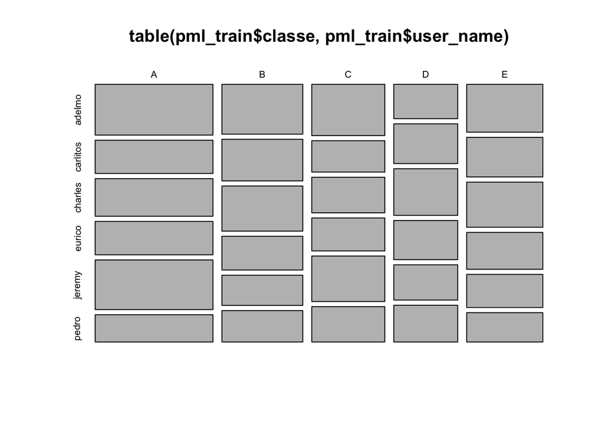

```r
round(prop.table(table(pml_train$new_window, pml_train$classe), 2), 3)
```

```
##
##           A     B     C     D     E
##   no  0.980 0.982 0.979 0.982 0.983
##   yes 0.020 0.018 0.021 0.018 0.017
```

We’re not concerned with time-dependent trends in the data, so we we exclude time-stamp variables.

```r
pml_names <- names(pml_train)
ind_excl <- match(c("X", "user_name", "new_window"), pml_names)
ind_excl <- c(ind_excl, grep("timestamp", pml_names))
```

Highly-correlated features are also excluded, using a correlation threshold of 80%.

```r
library(caret, warn.conflicts = FALSE)
ind_col2 <- setdiff(ind_col, ind_excl)
cor_train <- cor(pml_train[, ind_col2[1:length(ind_col2)-1]])
cor_vars <- findCorrelation(cor_train, cutoff = 0.8, names = TRUE)
ind_train <- setdiff(ind_col2, match(cor_vars, pml_names))
```

The number of variables has been reduced to 44. The data is split into training and testing sets with a ratio of 7:3.

```r
set.seed(39847)
inTrain <- createDataPartition( y = pml_train$classe, p=0.7, list=FALSE)
training <- pml_train[ inTrain, ind_train]
testing  <- pml_train[-inTrain, ind_train]
dim(training)
```

```
## [1] 3502   44
```

```r
dim(testing)
```

```
## [1] 1498   44
```

## Training

The following figure shows `classe` as a function of variable `num_window`. We notice that values of `num_window` form non-overlapping segments. Hence we can expect variable `num_window` to be a good predictor for `classe`.

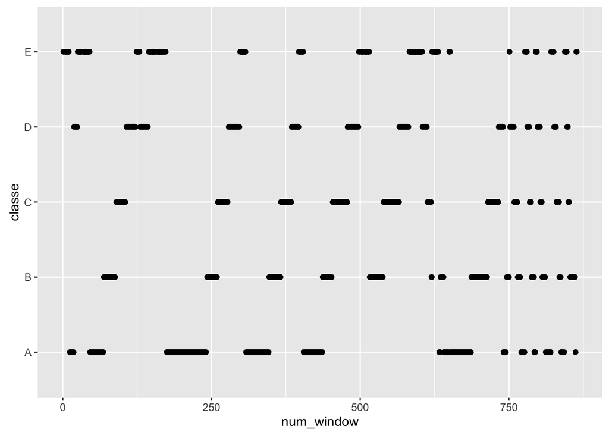

We first train a $k$-nearest neighbors model using `num_window` as the sole predictor.

```r
mod2 <- train(classe ~ num_window, method = "knn", data = training)
mod2
```

```
## k-Nearest Neighbors
##
## 3502 samples
##   43 predictor
##    5 classes: 'A', 'B', 'C', 'D', 'E'
##
## No pre-processing
## Resampling: Bootstrapped (25 reps)
## Summary of sample sizes: 3502, 3502, 3502, 3502, 3502, 3502, ...
## Resampling results across tuning parameters:
##
##   k  Accuracy   Kappa      Accuracy SD  Kappa SD
##   5  0.9738683  0.9668868  0.006514737  0.008223699
##   7  0.9684875  0.9600672  0.007006816  0.008826118
##   9  0.9639089  0.9542725  0.007209248  0.009064147
##
## Accuracy was used to select the optimal model using  the largest value.
## The final value used for the model was k = 5.
```

We see that the model has an expected accuracy of 97.4. Predicting with this model on the test data we get an accuracy of 98.3%.

```r
cm2 <- confusionMatrix(predict(mod2, testing), testing$classe)
cm2$overall["Accuracy"]
```

```
##  Accuracy
## 0.9826435
```

We next consider other variables in the data set to estimate out-of-sample error using cross-validation. We fit a **random forest** model with 50 trees excluding predictor `num_window`. We use **cross-validation** to tune the parameter `mtry`, the maximum number of randomly selected predictors. We try `mtry` values from 2 to 42.

```r
n_tree = 50
ctr1 <- trainControl(method = "repeatedcv", number = 10, repeats = 10)
tgd1 <- expand.grid(mtry = c(2, 5, 10, 20, 30, ncol(training)-2))
mod1 <- train(classe ~ . -num_window, method = "rf",
              data = training, ntree = n_tree,
              trControl = ctr1, tuneGrid = tgd1)
```

```r
mod1
```

```
## Random Forest
##
## 3502 samples
##   43 predictor
##    5 classes: 'A', 'B', 'C', 'D', 'E'
##
## No pre-processing
## Resampling: Cross-Validated (10 fold, repeated 10 times)
## Summary of sample sizes: 3151, 3152, 3153, 3154, 3150, 3152, ...
## Resampling results across tuning parameters:
##
##   mtry  Accuracy   Kappa      Accuracy SD  Kappa SD
##    2    0.9484885  0.9347266  0.01265821   0.01605718
##    5    0.9561971  0.9444943  0.01101595   0.01396912
##   10    0.9565963  0.9450002  0.01124300   0.01425578
##   20    0.9563400  0.9446812  0.01047697   0.01328162
##   30    0.9551424  0.9431624  0.01103061   0.01398486
##   42    0.9527410  0.9401212  0.01217505   0.01543284
##
## Accuracy was used to select the optimal model using  the largest value.
## The final value used for the model was mtry = 10.
```

```r
summary(mod1$resample$Accuracy)
```

```
##    Min. 1st Qu.  Median    Mean 3rd Qu.    Max.
##  0.9261  0.9513  0.9571  0.9566  0.9629  0.9800
```

The plot of accuracy for repeated cross-validation shows that the highest value occurs for `mtry` value of 10, wich is used in the final model.

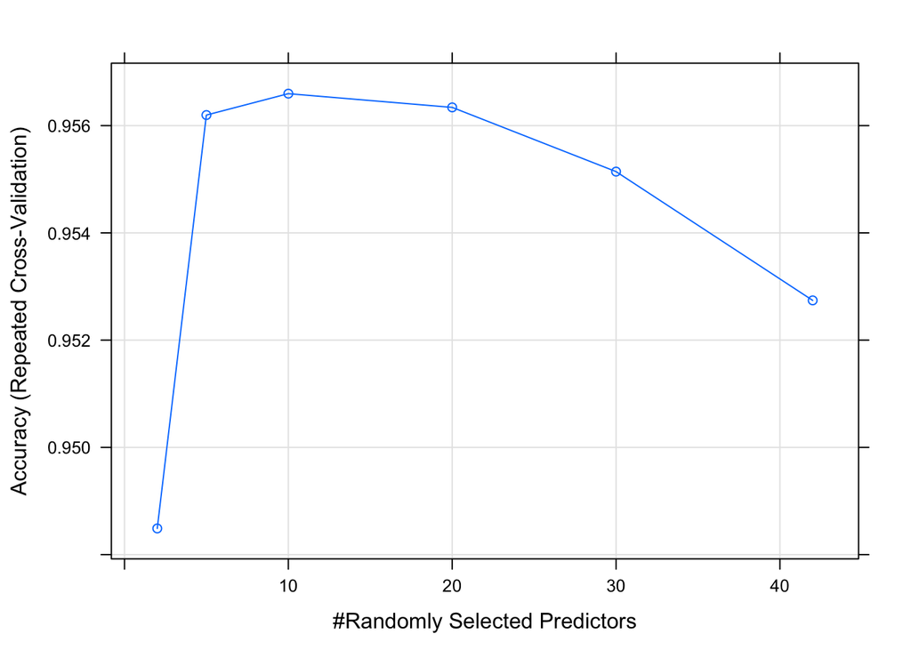

The model has an accuracy of about **95.6%** on the 30% of data set aside for testing, in line with the cross-validation estimate.

```r
cm1 <- confusionMatrix(predict(mod1, testing), testing$classe)
cm1$table
```

```
##           Reference
## Prediction   A   B   C   D   E
##          A 426  12   0   0   0
##          B   2 268  18   2   0
##          C   0  12 247  10   5
##          D   1   2   1 219   0
##          E   0   0   0   1 272
```

```r
cm1$overall["Accuracy"]
```

```
##  Accuracy
## 0.9559413
```

In addition to `num_window`, the following variable were found to be of high importance (see plot in Appendix):

- `yaw_belt`
- `pitch_forearm`
- `magnet_dumbbell_z`
- `magnet_belt_y`
- `magnet_dumbbell_y`
- `roll_forearm`

Finally we use the random forest model to classify the `pml_test` data (for quiz purposes).

```r
predict(mod1, pml_test)
```

```
##  [1] B A B A A B D B A A B C B A E E A B B B
## Levels: A B C D E
```

## Conclusions

- `num_window` is a very good predictor of outcome `classe`, even using a relatively simple `knn` model.
- A random forest model using accelerator data was shown to have ~95% accuracy.
- The test data accuracy is in line with the cross-validation estimate.

## References

1. Velloso, E.; Bulling, A.; Gellersen, H.; Ugulino, W.; Fuks, H. [Qualitative Activity Recognition of Weight Lifting Exercises](http://groupware.les.inf.puc-rio.br/har#ixzz44QfM3vCy). Proceedings of 4th International Conference in Cooperation with SIGCHI (Augmented Human ’13) . Stuttgart, Germany: ACM SIGCHI, 2013.

## Appendix

Plot of 20 most important variables by mean decrease of Gini statistic.

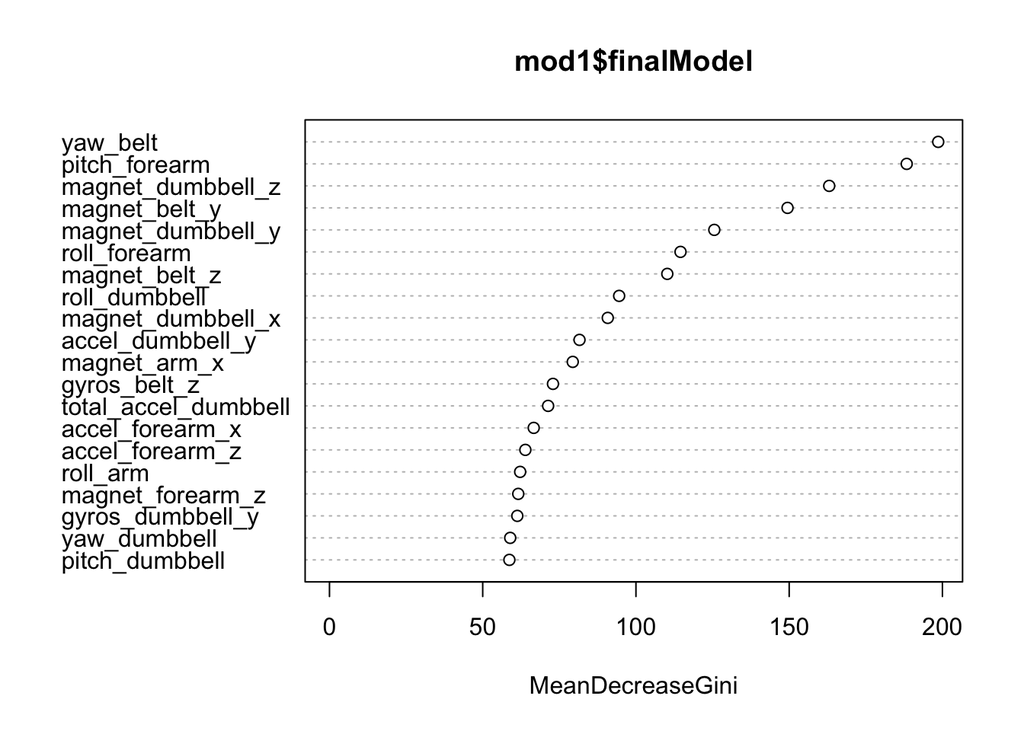

Plot of model error as a function of number of trees

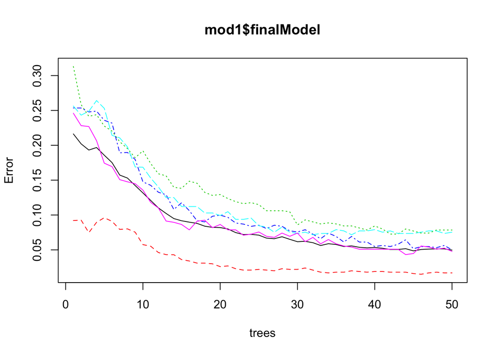